# 白葡萄酒质量分析_by chen xiaoxia

```
##
##  Pearson's product-moment correlation
##
## data:  wqw$pH and wqw$citric.acid
## t = -11.614, df = 4896, p-value < 2.2e-16
## alternative hypothesis: true correlation is not equal to 0
## 95 percent confidence interval:
##  -0.1908793 -0.1363671
## sample estimates:
##        cor
## -0.1637482
```

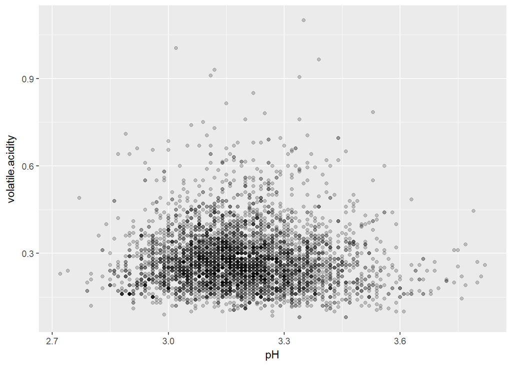

```
##
##  Pearson's product-moment correlation
##
## data:  wqw$pH and wqw$volatile.acidity
## t = -2.2343, df = 4896, p-value = 0.02551
## alternative hypothesis: true correlation is not equal to 0
## 95 percent confidence interval:
##  -0.059868312 -0.003912409
## sample estimates:
##         cor
## -0.03191537
```

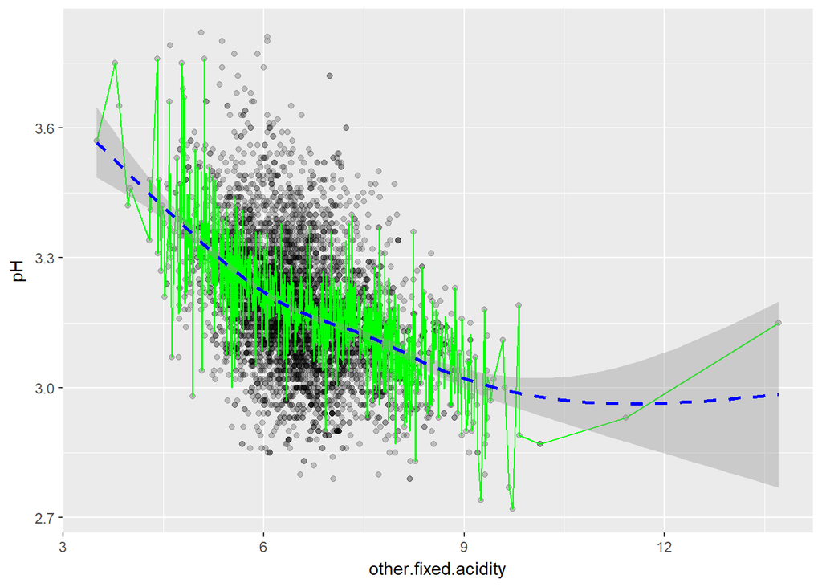

```
##
##  Pearson's product-moment correlation
##
## data:  wqw$pH and wqw$other.fixed.acidity
## t = -31.967, df = 4896, p-value < 2.2e-16
## alternative hypothesis: true correlation is not equal to 0
## 95 percent confidence interval:
##  -0.4384476 -0.3921006
## sample estimates:
##        cor
## -0.4155438
```

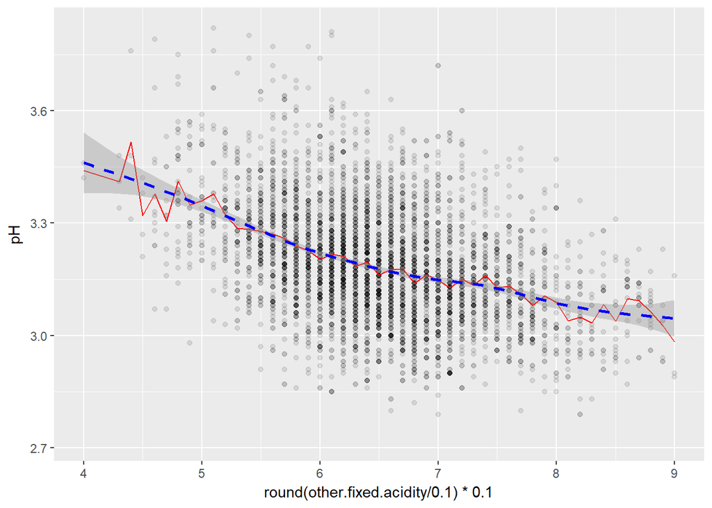

白葡萄酒中PH值与其他不挥发性酸(柠檬酸除外)呈负相关，相关系数-0.4155438

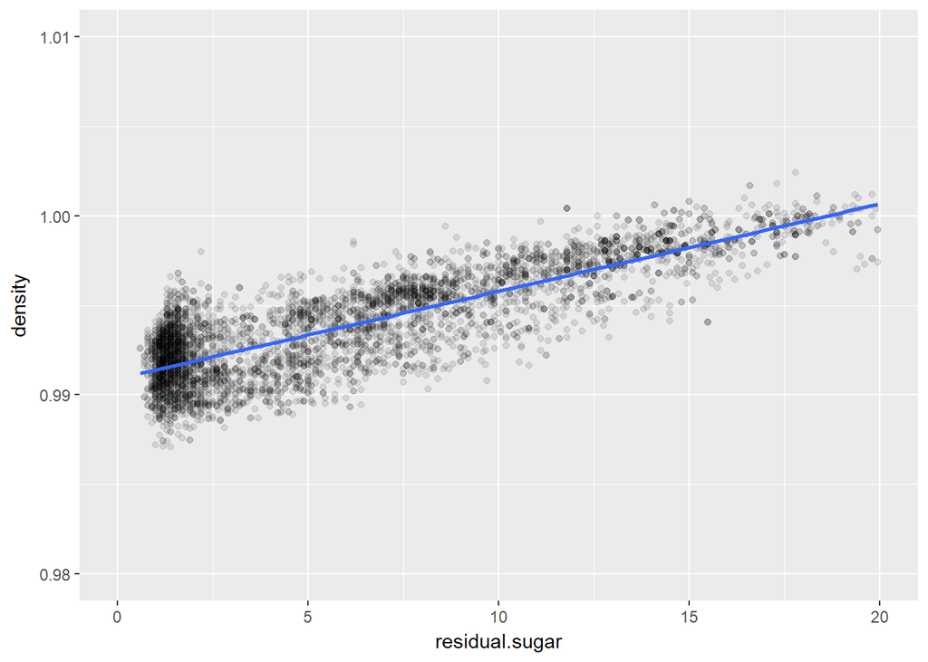

```
##
##  Pearson's product-moment correlation
##
## data:  wqw$residual.sugar and wqw$density
## t = 107.87, df = 4896, p-value < 2.2e-16
## alternative hypothesis: true correlation is not equal to 0
## 95 percent confidence interval:
##  0.8304732 0.8470698
## sample estimates:
##       cor
## 0.8389665
```

数据集中残糖含量与密度呈较强的正相关性，相关系数0.839，残糖含量越多，密度越大。

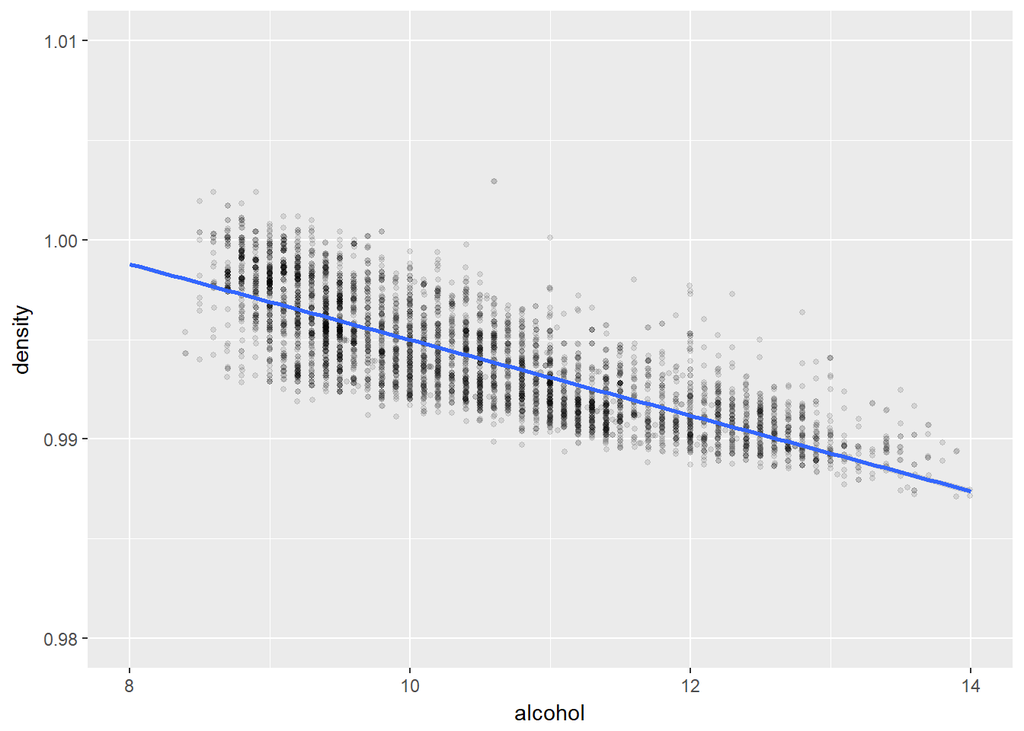

```
##
##  Pearson's product-moment correlation
##
## data:  wqw$alcohol and wqw$density
## t = -87.255, df = 4896, p-value < 2.2e-16
## alternative hypothesis: true correlation is not equal to 0
## 95 percent confidence interval:
##  -0.7908646 -0.7689315
## sample estimates:
##        cor
## -0.7801376
```

数据集中酒精含量与密度呈较强的负相关性，相关系数-0.78，酒精含量越多，密度越小。

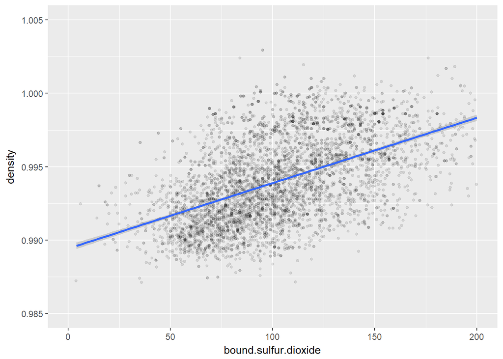

```
##
##  Pearson's product-moment correlation
##
## data:  wqw$bound.sulfur.dioxide and wqw$density
## t = 40.879, df = 4896, p-value < 2.2e-16
## alternative hypothesis: true correlation is not equal to 0
## 95 percent confidence interval:
##  0.4832679 0.5250358
## sample estimates:
##       cor
## 0.5044469
```

结合态二氧化硫含量与密度呈正相关性，结合态二氧化硫含量越高，密度越大

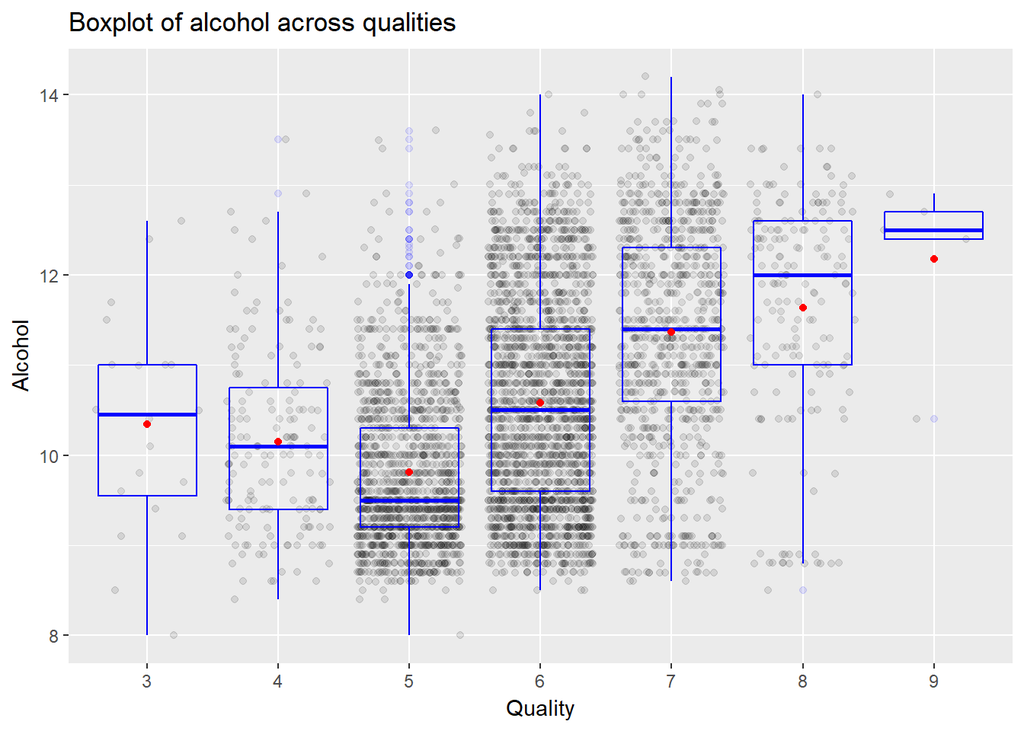

```
##
##  Pearson's product-moment correlation
##
## data:  wqw$alcohol and wqw$quality
## t = 33.858, df = 4896, p-value < 2.2e-16
## alternative hypothesis: true correlation is not equal to 0
## 95 percent confidence interval:
##  0.4126015 0.4579941
## sample estimates:
##       cor
## 0.4355747
```

白葡萄酒的质量评分与酒精度成正相关性，相关系数为0.436，酒精度越高，质量评分越高。

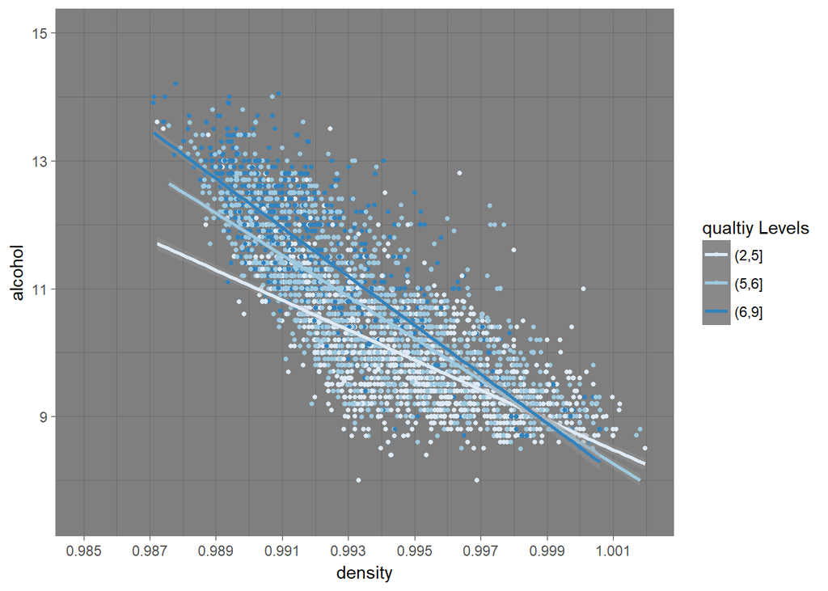

白葡萄酒的质量评分与密度呈负相关性，相关系数-0.307，密度越大，质量评分越低

# 双变量分析

### 探讨你在这部分探究中观察到的一些关系。这些感兴趣的特性与数据集内其他特性有什么区别？

残糖含量低于4克/立方分米时(干型白葡萄酒)，残糖含量对酒精度的影响较小，对于非干型白葡萄酒，残糖含量越高，能达到的酒精度数越低  
氯化物含量越高，酒精度越低  
残糖含量越多，密度越大  
结合态二氧化硫含量越高，密度越大  
酒精度越高，质量评分越高  
密度越大，质量评分越低  
其他不挥发性酸(柠檬酸除外)的含量越高，PH值越低  
这些特性与其他特性相比有比较高的相关性

### 你是否观察到主要特性与其他特性之间的有趣关系？

可以通过主要特性推导出其他特性，只是推导出的特性关系没有那么强  
通过氯化物含量越高酒精度越低，和酒精度越高质量评分越高，可得出氯化物含量越高质量评分越低  
通过结合态二氧化硫含量越高密度越大，和密度越大质量评分越低，可得出结合态二氧化硫含量越高质量评分越低

### 你发现最强的关系是什么？

最强的关系是残糖含量与密度的正相关性，相关系数0.839

# 多变量绘图选择

```
##  [1] "volatile.acidity"     "citric.acid"          "residual.sugar"
##  [4] "chlorides"            "free.sulfur.dioxide"  "density"
##  [7] "pH"                   "sulphates"            "alcohol"
## [10] "quality"              "other.fixed.acidity"  "bound.sulfur.dioxide"
```

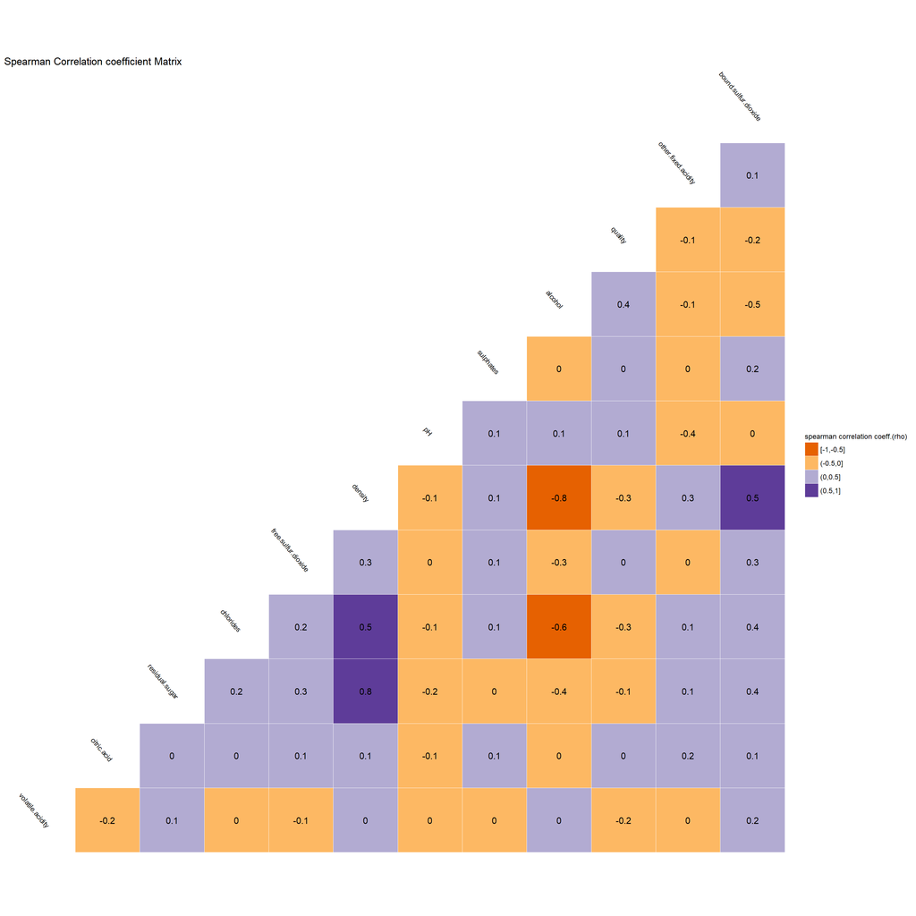

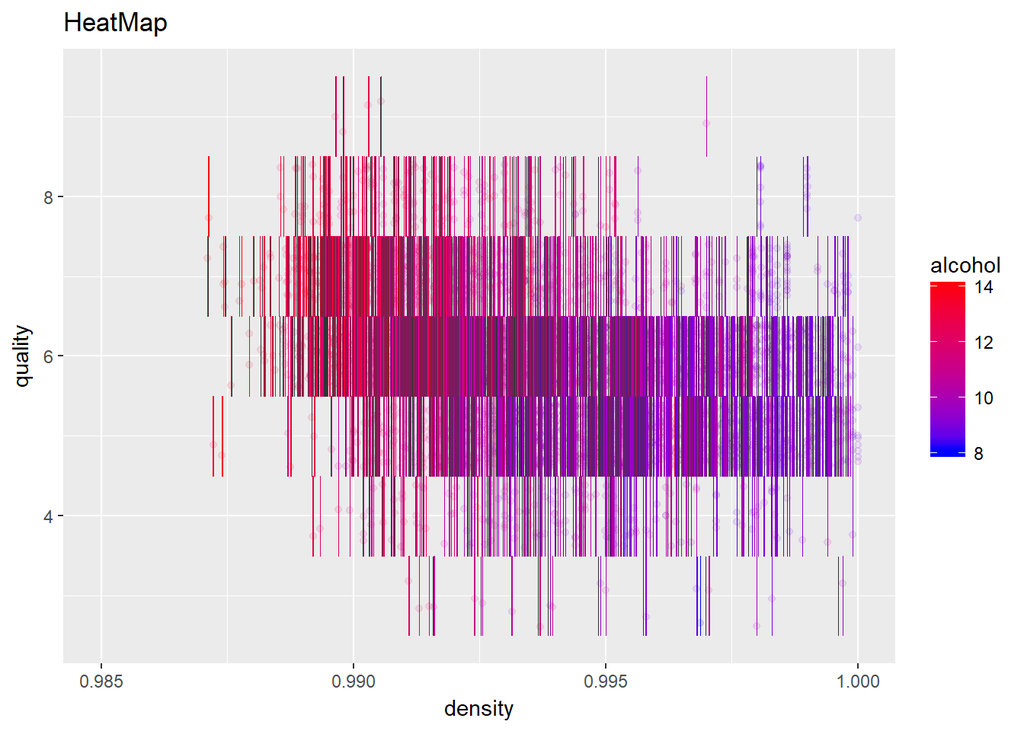

数据集中白葡萄酒的密度越低，质量评分越高；  
酒精度越高，质量评分越高；  
密度越低，酒精度越高  
酒精度和密度相互抑制，又都影响质量评分。

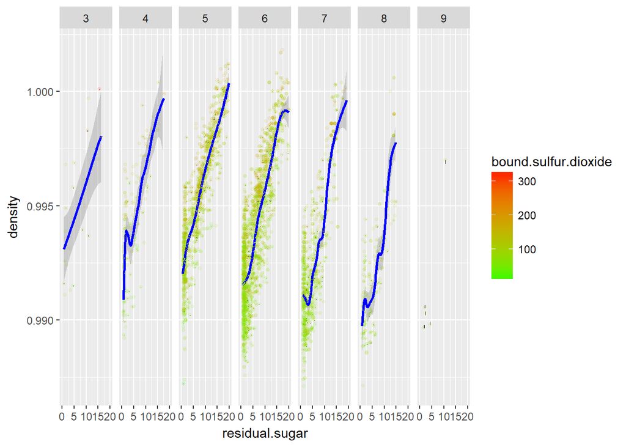

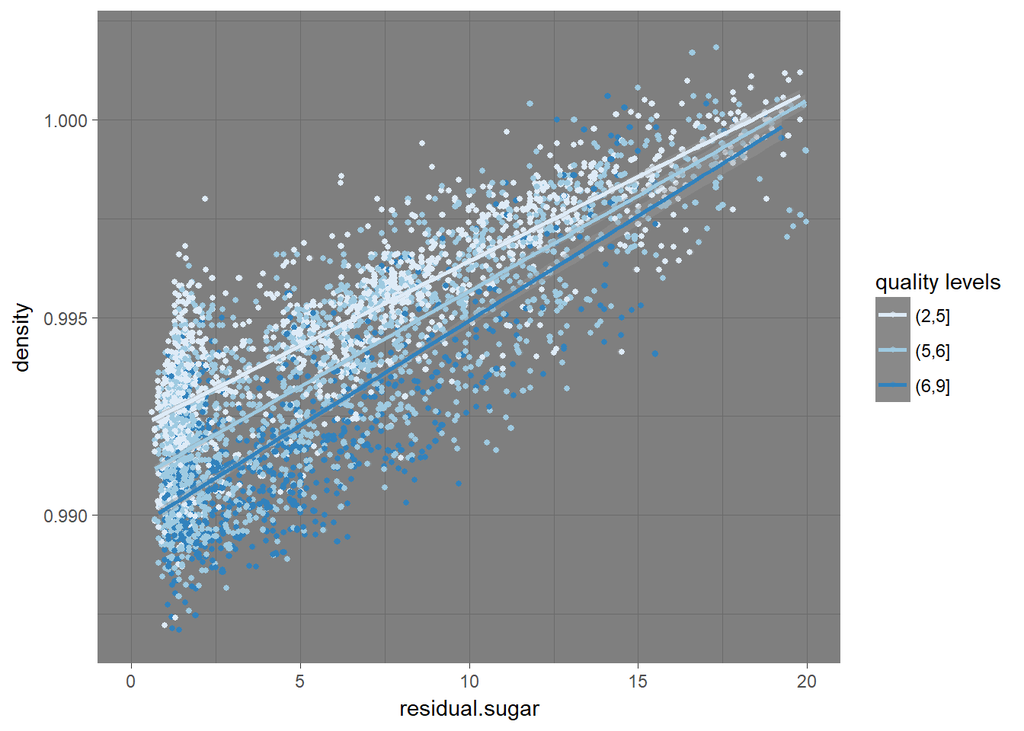

残糖含量越高，密度越大  
密度相同时，残糖含量越高，质量越高  
残糖含量相同时，密度越高，质量越低

```
##
## Calls:
## m1: glm(formula = quality ~ volatile.acidity, data = wqw_subset)
## m2: glm(formula = quality ~ volatile.acidity + residual.sugar, data = wqw_subset)
## m3: glm(formula = quality ~ volatile.acidity + residual.sugar + chlorides,
##     data = wqw_subset)
## m4: glm(formula = quality ~ volatile.acidity + residual.sugar + chlorides +
##     density, data = wqw_subset)
## m5: glm(formula = quality ~ volatile.acidity + residual.sugar + chlorides +
##     density + pH, data = wqw_subset)
## m6: glm(formula = quality ~ volatile.acidity + residual.sugar + chlorides +
##     density + pH + sulphates, data = wqw_subset)
## m7: glm(formula = quality ~ volatile.acidity + residual.sugar + chlorides +
##     density + pH + sulphates + alcohol, data = wqw_subset)
## m8: glm(formula = quality ~ volatile.acidity + residual.sugar + chlorides +
##     density + pH + sulphates + alcohol + other.fixed.acidity,
##     data = wqw_subset)
##
## ========================================================================================================================================
##                              m1            m2            m3            m4            m5            m6            m7            m8
## ----------------------------------------------------------------------------------------------------------------------------------------
##   (Intercept)               6.354***      6.436***      6.742***    225.858***    235.657***    245.216***    115.583***    152.469***
##                            (0.036)       (0.039)       (0.044)       (7.213)       (7.198)       (7.237)      (12.756)      (17.973)
##   volatile.acidity         -1.711***     -1.663***     -1.553***     -1.810***     -1.807***     -1.787***     -1.984***     -1.958***
##                            (0.123)       (0.123)       (0.121)       (0.111)       (0.110)       (0.109)       (0.109)       (0.109)
##   residual.sugar                         -0.015***     -0.012***      0.096***      0.106***      0.111***      0.071***      0.085***
##                                          (0.002)       (0.002)       (0.004)       (0.004)       (0.004)       (0.005)       (0.007)
##   chlorides                                            -7.756***     -2.096***     -1.382*       -1.266*       -0.373        -0.084
##                                                        (0.559)       (0.545)       (0.544)       (0.540)       (0.537)       (0.546)
##   density                                                          -221.314***   -233.788***   -243.589***   -114.531***   -152.376***
##                                                                      (7.285)       (7.307)       (7.349)      (12.779)      (18.223)
##   pH                                                                                0.784***      0.702***      0.485***      0.685***
##                                                                                    (0.076)       (0.076)       (0.077)       (0.103)
##   sulphates                                                                                       0.826***      0.605***      0.659***
##                                                                                                  (0.098)       (0.099)       (0.100)
##   alcohol                                                                                                       0.230***      0.188***
##                                                                                                                (0.019)       (0.024)
##   other.fixed.acidity                                                                                                         0.061**
##                                                                                                                              (0.021)
## ----------------------------------------------------------------------------------------------------------------------------------------
##   Aldrich-Nelson R-sq.      0.029         0.034         0.060         0.151         0.160         0.166         0.178         0.179
##   McFadden R-sq.            0.038         0.045         0.081         0.227         0.244         0.255         0.277         0.278
##   Cox-Snell R-sq.           0.029         0.035         0.062         0.163         0.174         0.181         0.195         0.196
##   Nagelkerke R-sq.          0.054         0.064         0.114         0.300         0.320         0.333         0.359         0.360
##   phi                       0.755         0.749         0.721         0.607         0.594         0.585         0.568         0.567
##   Likelihood-ratio        145.639       173.544       312.450       872.320       936.257       977.578      1062.914      1067.720
##   p                         0.000         0.000         0.000         0.000         0.000         0.000         0.000         0.000
##   Log-likelihood        -6259.952     -6241.388     -6146.829     -5723.715     -5670.394     -5635.305     -5561.211     -5556.970
##   Deviance               3695.351      3667.446      3528.539      2968.670      2904.733      2863.411      2778.076      2773.270
##   AIC                   12525.903     12490.776     12303.657     11459.430     11354.788     11286.610     11140.421     11133.940
##   BIC                   12545.393     12516.763     12336.140     11498.409     11400.264     11338.583     11198.890     11198.906
##   N                      4898          4898          4898          4898          4898          4898          4898          4898
## ========================================================================================================================================
```

线性回归模型中，R平方只有0.278，这些指标只解释了27.8%的质量评分

# 多变量分析

### 探讨你在这部分探究中观察到的一些关系。通过观察感兴趣的特性，是否存在相互促进的特性？

数据集中白葡萄酒的密度越低，质量评分越高；  
酒精度越高，质量评分越高；  
密度越低，酒精度越高  
酒精度和密度相互抑制，相互促进影响质量评分。

残糖含量越高，密度越大  
密度相同时，残糖含量越高，质量越高  
残糖含量相同时，密度越高，质量越低

### 这些特性之间是否存在有趣或惊人的联系呢？

残糖含量越高，密度越大  
密度相同时，残糖含量越高，质量越高  
残糖含量相同时，密度越高，质量越低

### 选项：你是否创建过数据集的任何模型？讨论你模型的优缺点。

创建了白葡萄酒质量评分和可能影响评分的理化指标的线性模型，模型的R平方只有0.278，即这些理化指标只解释了27.8%的质量评分。  
葡萄酒的质量不仅跟化学指标相关，还有一些感官指标，比如色泽，香气，滋味，产区等  
——

# 定稿图与总结

### 绘图一

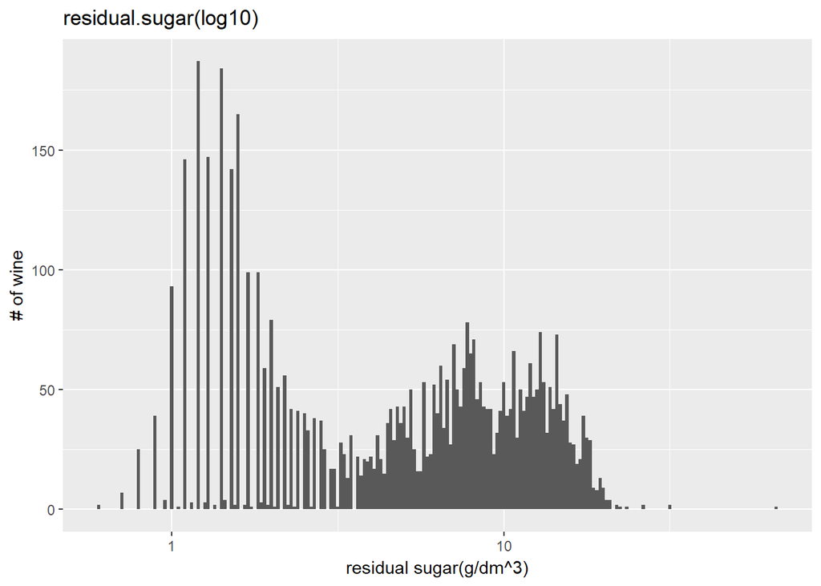

### 绘图二

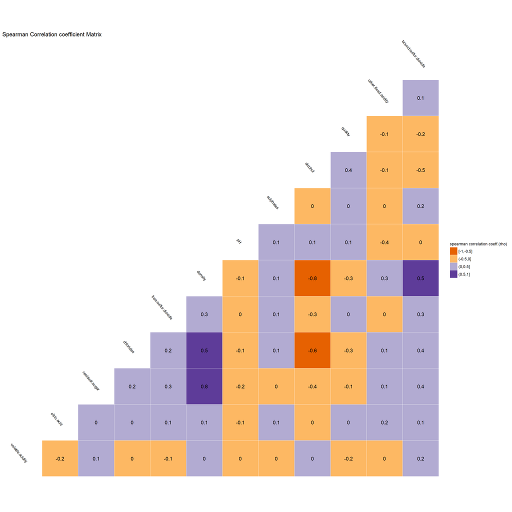

### 描述二

氯化物含量越高，酒精度越低  
残糖含量越多，密度越大  
结合态二氧化硫含量越高，密度越大  
酒精度越高，质量评分越高  
密度越大，质量评分越低  
其他不挥发性酸(柠檬酸除外)的含量越高，PH值越低  
这些指标之间有比较高的相关性  
最强的关系是残糖含量与密度的正相关性，相关系数0.839

### 绘图三

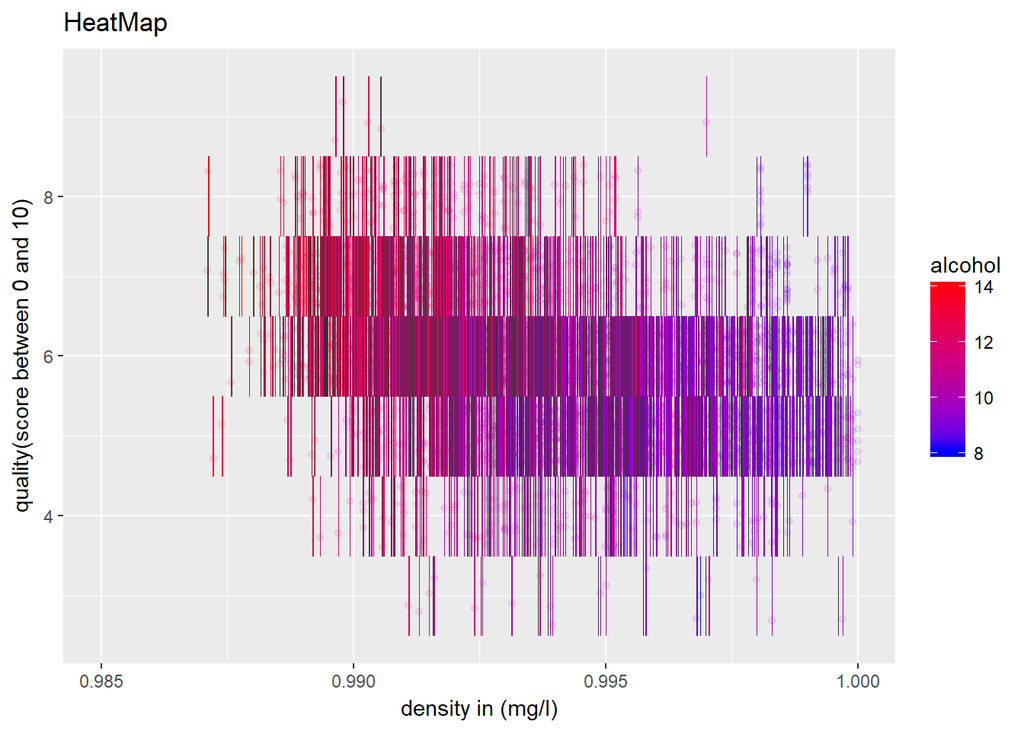

### 描述三

数据集中白葡萄酒的密度越低，质量评分越高；  
酒精度越高，质量评分越高；  
密度越低，酒精度越高  
酒精度和密度相互抑制，又都影响质量评分。

# 反思

对白葡萄酒的知识并不是特别了解，更多的是从数据层面进行分析。  
在白葡萄酒质量评分和可能影响评分的理化指标的线性模型中，模型的R平方只有0.278，即这些理化指标只解释了27.8%的质量评分。  
葡萄酒的质量不仅跟化学指标相关，还有一些感官指标，比如色泽，香气，滋味，产区等，如果可能可以加入感官指标的分析  
另外如果基于模型对白葡萄酒的质量进行预测，这个目前没有考虑

# 参考文献

1 P. Cortez, A. Cerdeira, F.Almeida, T. Matos and J. Reis. Modeling wine preferences by data mining from physicochemical properties. In Decision Support Systems, Elsevier, 47(4):547-553. ISSN: 0167-9236. Available at:

[@Elsevier] http://dx.doi.org/10.1016/j.dss.2009.05.016  
[Pre-press (pdf)] http://www3.dsi.uminho.pt/pcortez/winequalitv09.pdf  
[bib] http://www3.dsi.uminho.pt/pcortez/dss09.bih

2 http://www.wine-world.com/culture/pj/20160322151531855  
揭秘：葡萄酒中含有哪些秘密成分？